# Module 2 Report

SID: 430345827

## Data

The data was colected from students of DATA2002 in semester 2 of 2019 through a voluntary online survey. We will begin by reading in the data set and looking at the column names.

```r
library("tidyverse")
```

```r
data_original <- readr::read_csv("https://docs.google.com/spreadsheets/d/1hNeBWmVXTLyUwl6b9yTnfPn2jfbQuBdPJuhJu-FZJSo/export?gid=690048681&format=csv")
data = data_original
colnames(data)
```

```
##  [1] "Timestamp"
##  [2] "Identifier"
##  [3] "Gender"
##  [4] "Postcode of where you live during semester"
##  [5] "What statistics courses have you taken?"
##  [6] "How many university clubs are you a member of?"
##  [7] "How long has it been since you last went to the dentist?"
##  [8] "On average, how many hours per week did you spend on university work last semester?"
##  [9] "What is your favourite social media platform?"
## [10] "How many siblings do you have?"
## [11] "Did you have a pet growing up?"
## [12] "Do you currently live with your parents?"
## [13] "How many hours a week do you spend exercising?"
## [14] "What is your eye colour?"
## [15] "How many hours per week do you work in paid employment?"
## [16] "What is your favourite season of the year?"
## [17] "What is your shoe size?"
## [18] "How tall are you?"
## [19] "How often do you floss your teeth?"
## [20] "Do you wear glasses or contacts?"
## [21] "What is your dominant hand?"
## [22] "How do you like your steak cooked?"
```

We will now clean the data. The ‘clean_names’ function from the ‘janitor’ package was used to clean the names of the columns and then the ‘rename’ function to rename the column names for ease of use.

```r
data <- janitor::clean_names(data_original, 'snake') %>%
  rename(postcode = postcode_of_where_you_live_during_semester,
         units = what_statistics_courses_have_you_taken,
         clubs = how_many_university_clubs_are_you_a_member_of,
         dentist = how_long_has_it_been_since_you_last_went_to_the_dentist,
         study = on_average_how_many_hours_per_week_did_you_spend_on_university_work_last_semester,
         social_media = what_is_your_favourite_social_media_platform,
         siblings = how_many_siblings_do_you_have,
         exercise = how_many_hours_a_week_do_you_spend_exercising,
         pet_growing_up = did_you_have_a_pet_growing_up ,
         live_with_parents = do_you_currently_live_with_your_parents,
         eye_colour = what_is_your_eye_colour,
         hrs_employed = how_many_hours_per_week_do_you_work_in_paid_employment,
         fav_season = what_is_your_favourite_season_of_the_year,
         shoe_size = what_is_your_shoe_size,
         height = how_tall_are_you,
         floss_frequency = how_often_do_you_floss_your_teeth,
         glasses = do_you_wear_glasses_or_contacts,
         handedness = what_is_your_dominant_hand,
         doneness = how_do_you_like_your_steak_cooked)

# colnames(data)
```

Following this we saw that some entries were unrealistic; specifically those asking for the number of hours spent exercising, studying, and working during the week. Any numbers above 100 were removed using the ‘mutate’ function inconjunction with the ‘case_when’ function.

```r
data = data %>%
  mutate(exercise = as.numeric(exercise),
    exercise = case_when(
    exercise > 100 ~ NA_real_,
    TRUE ~ exercise)) %>%
  mutate(study = case_when(
    study > 100 ~ NA_real_,
    TRUE ~ study)) %>%
  mutate(hrs_employed = case_when(
    hrs_employed > 100 ~ NA_real_,
    TRUE ~ hrs_employed))
```

```r
data = data %>%
  mutate(height = case_when(
    height > 230 ~ NA_real_,
    height < 100 ~ NA_real_,
    TRUE ~ height))
```

The shoe size data presented a problem as there are many show sizing charts. Australian shoe sized were assumed where appropriate and European otherwise. There was also one case that was assumed to be in millimeters. The sizes were converted as I saw fit after consulting several shoe sizing charts. Many of the values had to be manually converted as per the code below. Again, we used the ‘mutate’ and ‘case_when’ functions.

```r
data = data %>%
  mutate(shoe_size = case_when(
    shoe_size < 3 ~ NA_real_,
    shoe_size > 15 & shoe_size < 35 ~ NA_real_,
    shoe_size == 36 ~ 4,
    shoe_size == 37 ~ 5,
    shoe_size == 37.5 ~ 5,
    shoe_size == 38 ~ 6,
    shoe_size == 40 ~ 7,
    shoe_size == 41 ~ 8,
    shoe_size == 42 ~ 8,
    shoe_size == 42.5 ~ 9,
    shoe_size == 43 ~ 9,
    shoe_size == 44 ~ 10,
    shoe_size == 45 ~ 11,
    shoe_size == 46 ~ 12,
    shoe_size == 285 ~ 12,
    shoe_size > 300 ~ NA_real_,
    TRUE ~ shoe_size))
```

We will also clean the column “gender” for which the input was varied. We will use the ‘recode_gender’ function from the ‘gendercodeR’ package to help us with this.

```r
# install.packages("remotes")
# remotes::install_github("ropenscilabs/gendercodeR")
data = data %>%
  mutate(gender = gendercodeR::recode_gender(gender))
```

We will now clean the social media column. First, we will make all entries to title case with the ‘str_to_title’ function from the ‘stringr’ package. Then we will recode any unusual entries with the ‘dplyr’ package’s ‘recode’ function. # Maybe we will also use ‘forcat’ package’s ‘fct_lump’ to lump together the variables with less than X entries.

```r
data = data %>%
  mutate(social_media = stringr::str_to_title(social_media),
         social_media = dplyr::recode(social_media,
                                      'Facebook Messenger' = "Facebook",
                                      'Fb' = "Facebook",
                                      'I Never Use Social Media.' = "None",
                                      'Ig' = "Instagram",
                                      'Titktok' = "Tiktok",
                                      'L I N K E D I N' = "Linkedin",
                                      '-=-=-' = "None"))
```

Finally, we will clean the eye colour column using the same functions we used for the social media column; ‘str_to_title’ from ‘stringr’, and ‘recode’ from ‘dplyr’.

```r
data = data %>%
  mutate(eye_colour = stringr::str_to_title(eye_colour),
         eye_colour = dplyr::recode(eye_colour,
                                    '&' = NA_character_,
                                    'Balack' = "Black",
                                    'Blood' = NA_character_,
                                    'Hazelnut' = "Hazel",
                                    'Null' = NA_character_))
```

With that we have finished cleaning our data and can move on to answering some questions.

## Questions

### 1 & 2. Is this a random sample of DATA2002 students? What are the potential biases in this data generation?

Short answer, no. The data was collected through a voluntary survey of DATA2002 students through a Google doc survey posted on Ed so it is not a random sample of DATA2002 students.

The survey contains 110 entries; a number less than the number of students enrolled in DATA2002. Being a voluntary survey, it is likely that students who are more active in the unit contributed to the survey.

Although voluntary sampling is a commonly used method for collecting data, it gives the collector no control over the sample. In this way, the sample is not random and is biased to students who volunteered.

Nonetheless, we shall persist.

### 3. Which variables are most likely to be subjected to this bias?

The variables most likely to be subjected to this bias are those that are can be related to a student’s lifestyle. This includes ‘live with parents’, ‘hours on uni work’, ‘hours employed’, and ‘dentist’.

For example, it could be likely that a students who lives at home has more hours to spend on uni work if they also do not working or are working only a few hours per week. They may also have visited the dentist not long ago.

### 4. Is there any evidence to suggest that there’s a difference in the amount of exercise done by people who eat red meat compared to people who don’t eat red meat?

First we will create a new column named ‘eats_red_meat’ to classify students accordingly based on their response in ‘doneness’. Students who replied with “I don’t eat red meat” will be denoted by ‘FALSE’ and all others with ‘TRUE’. We will also look at the distribution of ‘eats_red_meat’ and ‘exercise’ using the ‘ggplot’ package and the ‘geom_bar’ function.

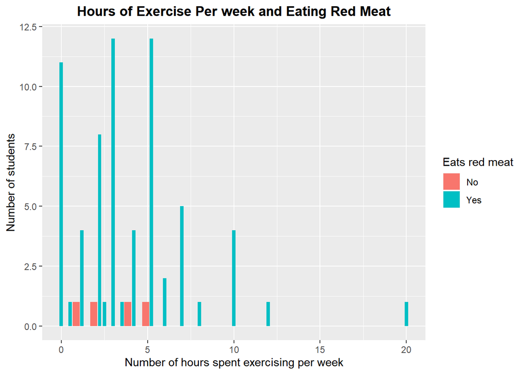

```r
data <- mutate(data, eats_red_meat = data$doneness!="I don't eat red meat")

data %>% na.omit(data$exercise) %>%
  ggplot(aes(exercise, fill = eats_red_meat)) +
  ggtitle("Hours of Exercise Per week and Eating Red Meat") +
  xlab("Number of hours spent exercising per week") +
  ylab("Number of students") +
  geom_bar(position = position_dodge2(width = 0.9, preserve = "single")) +
  scale_fill_discrete(name = "Eats red meat", labels = c("No","Yes")) +
  theme(plot.title = element_text(hjust = 0.5, face = 'bold'))
```

H<sub>0</sub>: There is no difference in the number of people who eat red meat compared to people who don’t eat red meat.

H<sub>1</sub>: There is a difference in the number of people who eat red meat compared to people who don’t eat red meat.

Assumptions: Observations within a sample are independent of each other, as are the two samples themselves.

We will perform a two sample t-test on ‘exercise’ and ‘eats_red_meat’.

```r
t.test(data$exercise, data$eats_red_meat, alternative = "two.sided", var.equal = TRUE)
```

```
##
##  Two Sample t-test
##
## data:  data$exercise and data$eats_red_meat
## t = 8.3774, df = 214, p-value = 7.14e-15
## alternative hypothesis: true difference in means is not equal to 0
## 95 percent confidence interval:
##  2.402201 3.880445
## sample estimates:
## mean of x mean of y
## 4.0771028 0.9357798
```

### 5. Is there any evidence that the weekly exercise time of students who participate in more than 3 university clubs is different to those who don’t?

H<sub>0</sub>: The weekly exercise of students who participate in more than three university clubs is the same to those who don’t.

H<sub>1</sub>: There is a difference in weekly exercise of students who participate in more than three univeristy clubs is the same to those who don’t.

Assumptions: Observations within a sample are independent of each other, as are the two samples themselves.

First we will mutate our data set to include a column based on whether or not the students are part of more than three clubs.

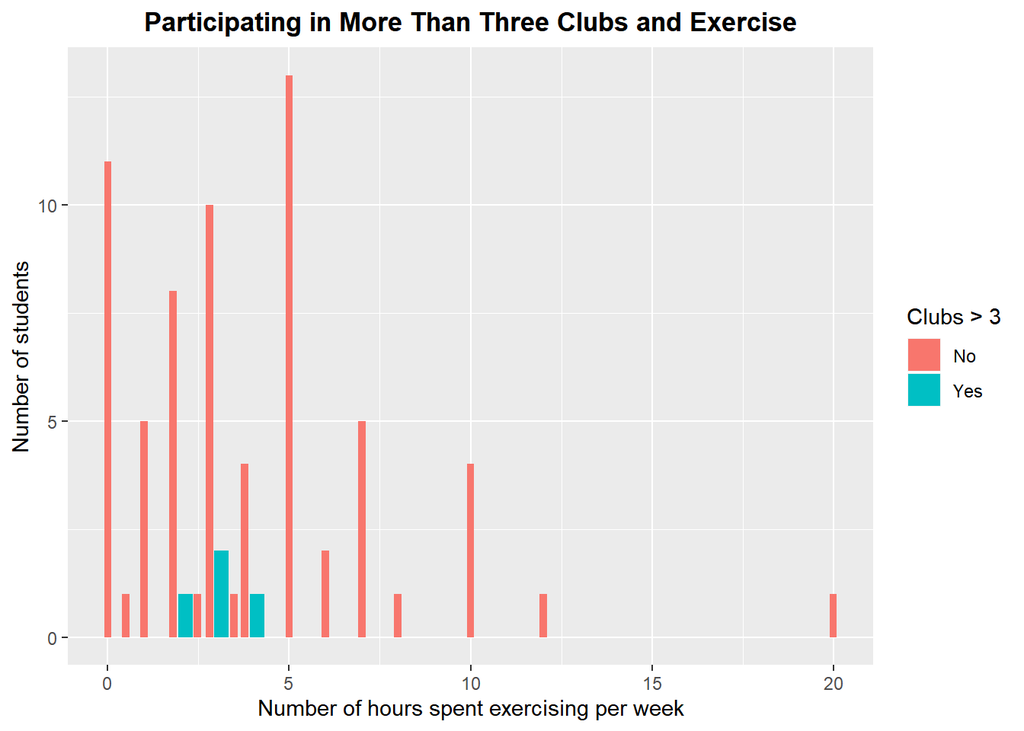

```r
data <- mutate(data, "more_than_three_clubs" = clubs>3)

data %>% na.omit(exercise) %>%
  ggplot(aes(exercise, fill = more_than_three_clubs)) +
  ggtitle("Participating in More Than Three Clubs and Exercise") +
  xlab("Number of hours spent exercising per week") +
  ylab("Number of students") +
  scale_fill_discrete(name = "Clubs > 3", labels = c("No","Yes")) +
  geom_bar(position = position_dodge2(width = 0.9, preserve = "single")) +
  theme(plot.title = element_text(hjust = 0.5, face = 'bold'))
```

We will now perform a two sample t-test on ‘more_than_three_clubs’ and ‘exercise’.

```r
t.test(data$more_than_three_clubs, data$exercise, alternative = "two.sided", var.equal = TRUE)
```

```
##
##  Two Sample t-test
##
## data:  data$more_than_three_clubs and data$exercise
## t = -10.644, df = 215, p-value < 2.2e-16
## alternative hypothesis: true difference in means is not equal to 0
## 95 percent confidence interval:
##  -4.713580 -3.240625
## sample estimates:
## mean of x mean of y
##  0.100000  4.077103
```

### 6. Is there evidence that students who live with their parents study more hours per week than students who don’t live with their parents?

H<sub>0</sub>: Students who live with their parents study the same number of hours per week than students who don’t live with their parents.

H<sub>1</sub>: There is a difference in the number of hours per week that students who live with their parents study to students who don’t live with their parents.

Assumptions: Observations within a sample are independent of each other, as are the two samples themselves.

First we will mutate the ‘live_with_parents’ so that it is either ‘TRUE’ or ‘FALSE’ instead of ‘Yes’ and ‘No’, respectively.

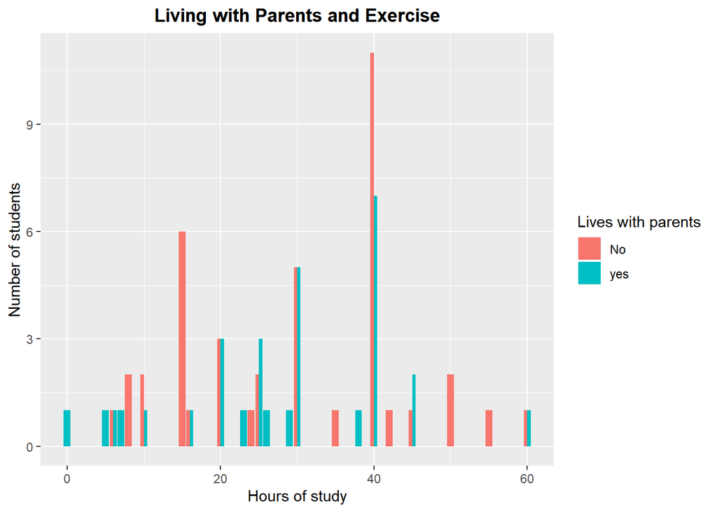

```r
data = data %>%
  mutate(live_with_parents = case_when(
    live_with_parents=="Yes" ~ TRUE,
    live_with_parents=="No" ~ FALSE,
    TRUE ~ NA))

data %>% na.omit(study) %>%
  ggplot(aes(study, fill = live_with_parents)) +
  ggtitle("Living with Parents and Exercise") +
  xlab("Hours of study") +
  ylab("Number of students") +
  geom_bar(position = "dodge") +
  scale_fill_discrete(name = "Lives with parents", labels = c("No","yes")) +
  theme(plot.title = element_text(hjust = 0.5, face = 'bold'))
```

```r
t.test(data$live_with_parents, data$exercise, alternative = "two.sided", var.equal = TRUE)
```

```
##
##  Two Sample t-test
##
## data:  data$live_with_parents and data$exercise
## t = -9.6138, df = 214, p-value < 2.2e-16
## alternative hypothesis: true difference in means is not equal to 0
## 95 percent confidence interval:
##  -4.371314 -2.883809
## sample estimates:
## mean of x mean of y
## 0.4495413 4.0771028
```

It would have been better to do a Wilcoxon rank sum test since the data is not normal; it is right skewed. However, to do so for discrete data as we have here is unclear to me. This makes the test performed above unreliable.

### 7. What other questions could you ask?

Another question we could ask is whether there is an association between the number of hours studied and the number of siblings a student has.

H<sub>0</sub>: There is no association between the number of hours studied and the number of siblings a student has.

H<sub>1</sub>: There is an association between the number of hours studied and the number of siblings a student has

Assumptions: e<sub>ij</sub> = y<sub>i</sub>.y<sub>j</sub>/n >= 5.

```r
siblings = data %>%
  select(siblings, study) %>%
  drop_na(siblings) %>%
  group_by(siblings, study) %>%
  count()

c_mat = xtabs(n ~ siblings + study, siblings)

fisher.test(c_mat, simulate.p.value = TRUE)
```

```
##
##  Fisher's Exact Test for Count Data with simulated p-value (based
##  on 2000 replicates)
##
## data:  c_mat
## p-value = 0.5287
## alternative hypothesis: two.sided
```

## References

R Core Team (2018). R: A language and environment for statistical computing. R Foundation for Statistical Computing, Vienna, Austria. URL: https://www.R-project.org/ (https://www.R-project.org/).

Hadley Wickham, Romain François, Lionel Henry and Kirill Müller (2018). dplyr: A Grammar of Data Manipulation. R package version 0.7.6. https://CRAN.R-project.org/package=dplyr (https://CRAN.Rproject. org/package=dplyr)

Hadley Wickham. ggplot2: Elegant Graphics for Data Analysis. Springer-Verlag New York, 2016.

Hadley Wickham (2017). tidyverse: Easily Install and Load the ‘Tidyverse’. R package version 1.2.1. https://CRAN.R-project.org/package=tidyverse (https://CRAN.R-project.org/package=tidyverse)